# Context

Business communities in the United States are facing high demand for human resources, but one of the constant challenges is identifying and attracting the right talent, which is perhaps the most important element in remaining competitive. Companies in the United States look for hard-working, talented, and qualified individuals both locally as well as abroad.

The Immigration and Nationality Act (INA) of the US permits foreign workers to come to the United States to work on either a temporary or permanent basis. The act also protects US workers against adverse impacts on their wages or working conditions by ensuring US employers' compliance with statutory requirements when they hire foreign workers to fill workforce shortages. The immigration programs are administered by the Office of Foreign Labor Certification (OFLC).

OFLC processes job certification applications for employers seeking to bring foreign workers into the United States and grants certifications in those cases where employers can demonstrate that there are not sufficient US workers available to perform the work at wages that meet or exceed the wage paid for the occupation in the area of intended employment.

# Objective

In FY 2016, the OFLC processed 775,979 employer applications for 1,699,957 positions for temporary and permanent labor certifications. This was a nine percent increase in the overall number of processed applications from the previous year. The process of reviewing every case is becoming a tedious task as the number of applicants is increasing every year.

The increasing number of applicants every year calls for a Machine Learning based solution that can help in shortlisting the candidates having higher chances of VISA approval. OFLC has hired the firm EasyVisa for data-driven solutions. You as a data scientist at EasyVisa have to analyze the data provided and, with the help of a classification model:

Facilitate the process of visa approvals. Recommend a suitable profile for the applicants for whom the visa should be certified or denied based on the drivers that significantly influence the case status.

# Data Description

The data contains the different attributes of the employee and the employer. The detailed data dictionary is given below.

### Data Dictionary

- case_id: ID of each visa application
- continent: Information of continent the employee
- education_of_employee: Information of education of the employee
- has_job_experience: Does the employee has any job experience? Y= Yes; N = No
- requires_job_training: Does the employee require any job training? Y = Yes; N = No
- no_of_employees: Number of employees in the employer's company
- yr_of_estab: Year in which the employer's company was established
- region_of_employment: Information of foreign worker's intended region of employment in the US.
- prevailing_wage: Average wage paid to similarly employed workers in a specific occupation in the area of intended employment. The purpose of the prevailing wage is to ensure that the foreign worker is not underpaid compared to other workers offering the same or similar service in the same area of employment.
- unit_of_wage: Unit of prevailing wage. Values include Hourly, Weekly, Monthly, and Yearly.
- full_time_position: Is the position of work full-time? Y = Full-Time Position; N = Part-Time Position
- case_status: Flag indicating if the Visa was certified or denied

```python
# import warnings library to hide warning and deprecation messages
import warnings
warnings.filterwarnings("ignore")

# import data handling and numeric processing libraries
import pandas as pd
import numpy as np

# import visualizations and chart libraries
import seaborn as sns
import matplotlib.pyplot as plt

# command to display plots in the notebook
%matplotlib inline

# set styling options
sns.set_style('darkgrid')

# import libraries for variable scaling
from sklearn.preprocessing import StandardScaler, MinMaxScaler, normalize, PolynomialFeatures

from scipy import stats

# imort vif function
from statsmodels.stats.outliers_influence import variance_inflation_factor

# import library to split data
from sklearn.model_selection import train_test_split

# import stats model
import statsmodels.api as sm

# import function to add constant
from statsmodels.tools.tools import add_constant

# import Logistic Regression function
from sklearn.linear_model import LogisticRegression

# import scoring metrics
from sklearn import metrics

from sklearn.metrics import (
    f1_score,
    accuracy_score,
    recall_score,
    precision_score,
    confusion_matrix,
    roc_auc_score,
    plot_confusion_matrix,
    precision_recall_curve,
    roc_curve,
    make_scorer,
    classification_report,
)

# import libraries to build decision tree classifier
from sklearn.tree import DecisionTreeClassifier
from sklearn import tree

# import library tune different models
from sklearn.model_selection import GridSearchCV
from sklearn.model_selection import RandomizedSearchCV

# Libraries to import different ensemble classifiers

# Bagging classifiers
import sys
!{sys.executable} -m pip install xgboost
from sklearn.ensemble import BaggingClassifier
from sklearn.ensemble import RandomForestClassifier

# Boosting classifiers
from sklearn.ensemble import AdaBoostClassifier, GradientBoostingClassifier
from xgboost import XGBClassifier

from xgboost import plot_importance
```

```python
# import the data
data = pd.read_csv('EasyVisa.csv')
```

```python
data.head()
```

|  | case_id | continent | education_of_employee | has_job_experience | requires_job_training | no_of_employees | yr_of_estab | region_of_employment | prevailing_wage | unit_of_wage | full_time_position | case_status |
| --- | --- | --- | --- | --- | --- | --- | --- | --- | --- | --- | --- | --- |
| 0 | EZYV01 | Asia | High School | N | N | 14513 | 2007 | West | 592.2029 | Hour | Y | Denied |
| 1 | EZYV02 | Asia | Master's | Y | N | 2412 | 2002 | Northeast | 83425.6500 | Year | Y | Certified |
| 2 | EZYV03 | Asia | Bachelor's | N | Y | 44444 | 2008 | West | 122996.8600 | Year | Y | Denied |
| 3 | EZYV04 | Asia | Bachelor's | N | N | 98 | 1897 | West | 83434.0300 | Year | Y | Denied |
| 4 | EZYV05 | Africa | Master's | Y | N | 1082 | 2005 | South | 149907.3900 | Year | Y | Certified |

```python
# get basic data info
data.info()
```

```
<class 'pandas.core.frame.DataFrame'>
RangeIndex: 25480 entries, 0 to 25479
Data columns (total 12 columns):
 #   Column                 Non-Null Count  Dtype
---  ------                 --------------  -----
 0   case_id                25480 non-null  object
 1   continent              25480 non-null  object
 2   education_of_employee  25480 non-null  object
 3   has_job_experience     25480 non-null  object
 4   requires_job_training  25480 non-null  object
 5   no_of_employees        25480 non-null  int64
 6   yr_of_estab            25480 non-null  int64
 7   region_of_employment   25480 non-null  object
 8   prevailing_wage        25480 non-null  float64
 9   unit_of_wage           25480 non-null  object
 10  full_time_position     25480 non-null  object
 11  case_status            25480 non-null  object
dtypes: float64(1), int64(2), object(9)
memory usage: 2.3+ MB
```

```python
data.shape
```

```
(25480, 12)
```

- The data contains 2 integer, 9 object and 1 float variables
- The data contains 25,480 observations
- There are 10 features in the data set and 1 target column
- The data contains case_id which doesn't affect the analysis

```python
# Let's check duplicate values
data[data.duplicated()].count()
```

```
case_id                  0
continent                0
education_of_employee    0
has_job_experience       0
requires_job_training    0
no_of_employees          0
yr_of_estab              0
region_of_employment     0
prevailing_wage          0
unit_of_wage             0
full_time_position       0
case_status              0
dtype: int64
```

- There are no duplicate values in the data set

```python
# Check missing values
data.isnull().sum()
```

```
case_id                  0
continent                0
education_of_employee    0
has_job_experience       0
requires_job_training    0
no_of_employees          0
yr_of_estab              0
region_of_employment     0
prevailing_wage          0
unit_of_wage             0
full_time_position       0
case_status              0
dtype: int64
```

- There are no missing values in the data set

```python
# Let's summarize the numerical columns
data.describe().T
```

|  | count | mean | std | min | 25% | 50% | 75% | max |
| --- | --- | --- | --- | --- | --- | --- | --- | --- |
| no_of_employees | 25480.0 | 5667.043210 | 22877.928848 | -26.0000 | 1022.00 | 2109.00 | 3504.0000 | 602069.00 |
| yr_of_estab | 25480.0 | 1979.409929 | 42.366929 | 1800.0000 | 1976.00 | 1997.00 | 2005.0000 | 2016.00 |
| prevailing_wage | 25480.0 | 74455.814592 | 52815.942327 | 2.1367 | 34015.48 | 70308.21 | 107735.5125 | 319210.27 |

- The numerical columns has both discrete and continuous data
- The mininum value for no_of_employees is -26. The number of emloyees should be positive value. We need to handle this in data cleaning
- The mean is higher than median for prevailing_wage, indicating right skew

```python
# Let's summarize the categorical columns
data.describe(include=["object"]).T
```

|  | count | unique | top | freq |
| --- | --- | --- | --- | --- |
| case_id | 25480 | 25480 | EZYV13808 | 1 |
| continent | 25480 | 6 | Asia | 16861 |
| education_of_employee | 25480 | 4 | Bachelor's | 10234 |
| has_job_experience | 25480 | 2 | Y | 14802 |
| requires_job_training | 25480 | 2 | N | 22525 |
| region_of_employment | 25480 | 5 | Northeast | 7195 |
| unit_of_wage | 25480 | 4 | Year | 22962 |
| full_time_position | 25480 | 2 | Y | 22773 |
| case_status | 25480 | 2 | Certified | 17018 |

```python
# Let's check data for all object data
x_columns = ['continent', 'education_of_employee', 'has_job_experience','requires_job_training', 'region_of_employment', 'unit_of_wage','full_time_position', 'case_status']
for i in x_columns:
    print(data[i].value_counts())
    print("-" * 50)
```

```
Asia             16861
Europe            3732
North America     3292
South America      852
Africa             551
Oceania            192
Name: continent, dtype: int64
--------------------------------------------------
Bachelor's     10234
Master's        9634
High School     3420
Doctorate       2192
Name: education_of_employee, dtype: int64
--------------------------------------------------
Y    14802
N    10678
Name: has_job_experience, dtype: int64
--------------------------------------------------
N    22525
Y     2955
Name: requires_job_training, dtype: int64
--------------------------------------------------
Northeast    7195
South        7017
West         6586
Midwest      4307
Island        375
Name: region_of_employment, dtype: int64
--------------------------------------------------
Year     22962
Hour      2157
Week       272
Month       89
Name: unit_of_wage, dtype: int64
--------------------------------------------------
Y    22773
N     2707
Name: full_time_position, dtype: int64
--------------------------------------------------
Certified    17018
Denied        8462
Name: case_status, dtype: int64
--------------------------------------------------
```

- All of the variables above have sensible values
- There are ordered and unordered features in the data set
- There aren't any custom values
- Let's understand these values more in EDA

## Processing before EDA

- Let's drop Case ID column as it provides no value in analysis
- Let's appropriate columns to category for better EDA analysis

```python
# drop case_id
data.drop('case_id', inplace=True, axis=1)
```

```python
data.info()
```

```
<class 'pandas.core.frame.DataFrame'>
RangeIndex: 25480 entries, 0 to 25479
Data columns (total 11 columns):
 #   Column                 Non-Null Count  Dtype
---  ------                 --------------  -----
 0   continent              25480 non-null  object
 1   education_of_employee  25480 non-null  object
 2   has_job_experience     25480 non-null  object
 3   requires_job_training  25480 non-null  object
 4   no_of_employees        25480 non-null  int64
 5   yr_of_estab            25480 non-null  int64
 6   region_of_employment   25480 non-null  object
 7   prevailing_wage        25480 non-null  float64
 8   unit_of_wage           25480 non-null  object
 9   full_time_position     25480 non-null  object
 10  case_status            25480 non-null  object
dtypes: float64(1), int64(2), object(8)
memory usage: 2.1+ MB
```

```python
for col in ['continent','education_of_employee','has_job_experience','requires_job_training','region_of_employment','unit_of_wage','full_time_position','case_status']:
    data[col] = data[col].astype('category')
#'yr_of_estab'
```

```python
data.info()
```

```
<class 'pandas.core.frame.DataFrame'>
RangeIndex: 25480 entries, 0 to 25479
Data columns (total 11 columns):
 #   Column                 Non-Null Count  Dtype
---  ------                 --------------  -----
 0   continent              25480 non-null  category
 1   education_of_employee  25480 non-null  category
 2   has_job_experience     25480 non-null  category
 3   requires_job_training  25480 non-null  category
 4   no_of_employees        25480 non-null  int64
 5   yr_of_estab            25480 non-null  int64
 6   region_of_employment   25480 non-null  category
 7   prevailing_wage        25480 non-null  float64
 8   unit_of_wage           25480 non-null  category
 9   full_time_position     25480 non-null  category
 10  case_status            25480 non-null  category
dtypes: category(8), float64(1), int64(2)
memory usage: 797.7 KB
```

# Exploratory Data Analysis (EDA)

### Univariate Analysis

```python
def Hist_Bar_Plt(variable,title):
    """This function plots histogram and bar plot
       for the input variable. The histogram plots
       shows mean and median lines."""

    fig, ax = plt.subplots(nrows=2,figsize=(15,12))

    fig.suptitle(f'Histogram and Boxplot for {title}')

    mean = variable.mean()
    median = variable.median()
    sns.histplot(x=variable, ax=ax[0], kde=True)
    ax[0].axvline(mean, color='r', linestyle='-', label="Mean")
    ax[0].axvline(median, color='b', linestyle='-', label="Median")
    ax[0].legend()

    sns.boxplot(ax=ax[1],x=variable,showmeans=True,palette="Set2")
    fig.show()
```

```python
# list all the numeric columns
num_cols = data.select_dtypes([np.number]).columns
```

```python
# list all the categorical columns
cat_cols = data.columns[data.dtypes == 'category']
```

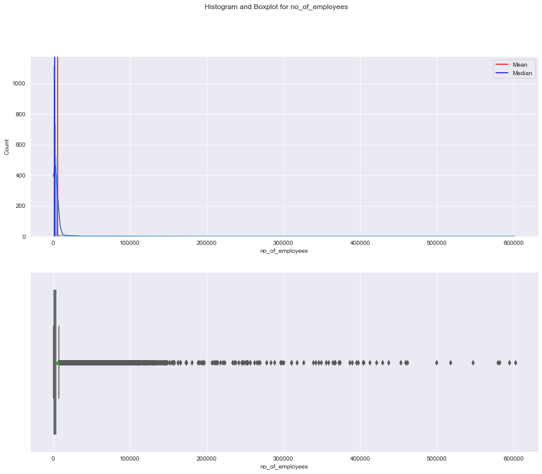

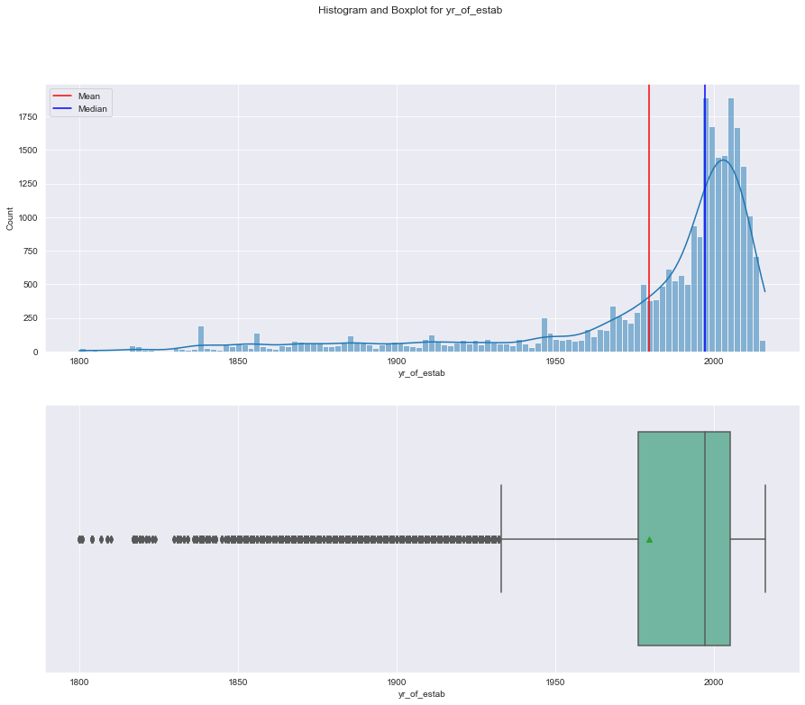

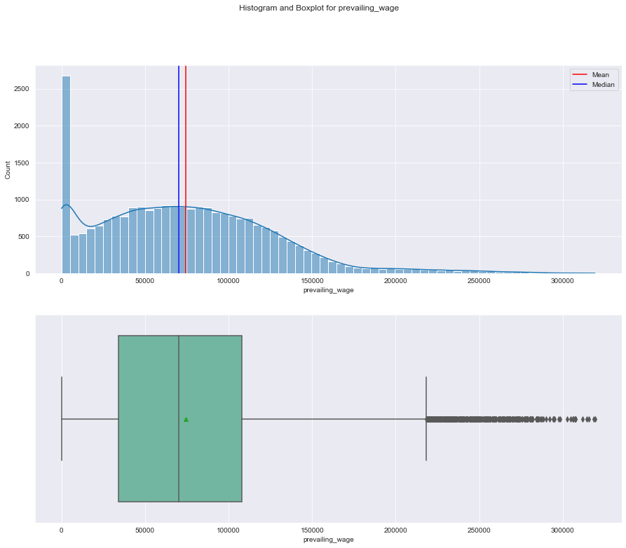

```python
# plotting numerical columns graphs
for i in num_cols:
    Hist_Bar_Plt(data[i],i)
```

```python
def labeled_barplot(data, feature, perc=False, n=None):
    """
    Barplot with percentage at the top
    data: dataframe
    feature: dataframe column
    perc: whether to display percentages instead of count (default is False)
    n: displays the top n category levels (default is None, i.e., display all levels)
    """
    total = len(data[feature])  # length of the column
    count = data[feature].nunique()
    if n is None:
        plt.figure(figsize=(count + 2, 6))
    else:
        plt.figure(figsize=(n + 2, 6))

    plt.xticks(rotation=90, fontsize=15)
    ax = sns.countplot(data=data,x=feature,
        palette="Paired", order=data[feature].value_counts().index[:n].sort_values(),
    )

    for p in ax.patches:
        if perc == True:
            label = "{:.1f}%".format(
                100 * p.get_height() / total
            )  # percentage of each class of the category
        else:
            label = p.get_height()  # count of each level of the category

        x = p.get_x() + p.get_width() / 2  # width of the plot
        y = p.get_height()  # height of the plot

        ax.annotate(
            label,
            (x, y),
            ha="center",
            va="center",
            size=12,
            xytext=(0, 5),
            textcoords="offset points",
        )  # annotate the percentage

    plt.show()
```

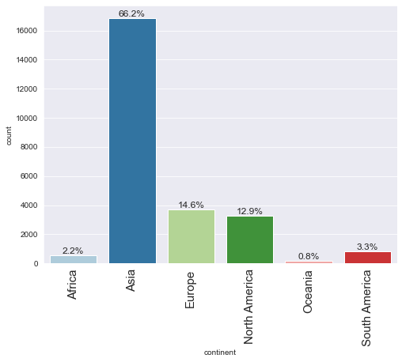

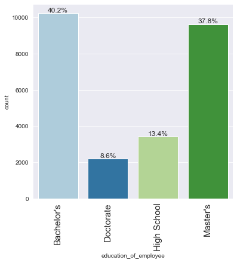

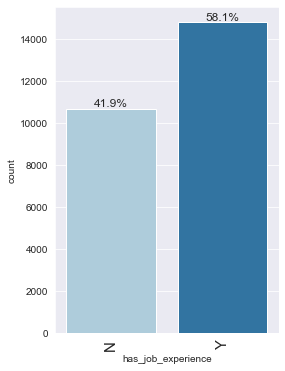

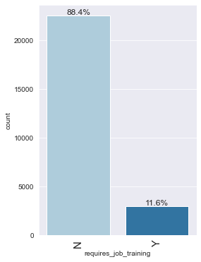

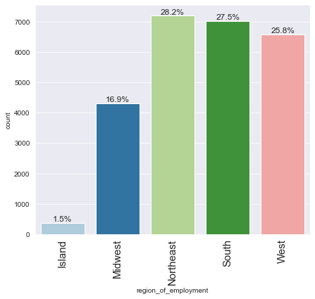

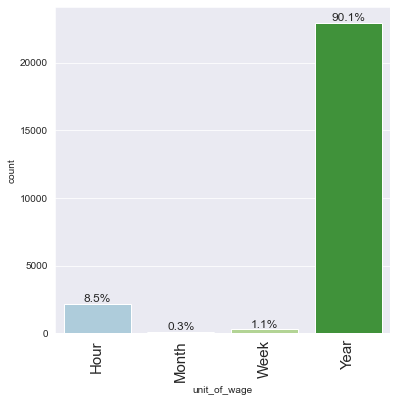

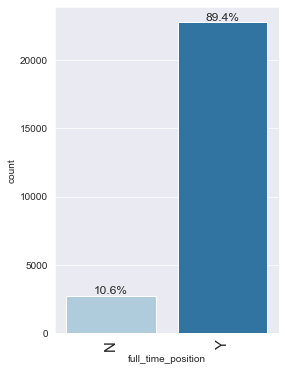

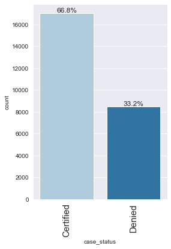

```python
# plotting categorical columns graphs
for i in cat_cols:
    labeled_barplot(data, i, perc=True)
```

### Summary of Univariate Analysis of the Categorical Variables

- continent: 66% of the cases are for Asia continent, followed by 14.6% cases from Europe. Oceania has least cases with 0.8% of total
- education of employee: 40% of employees have Bachelors education, followed by 37% with Masters. There are 8.6% employees who have a doctorate.
- has job experience: 58% of employees have previous job experience
- require job training: 88% of employees don't require job training
- year - year has a large range
- region of employment - Northeast, South and West regions have fairly equal number of cases
- unit of wage: 90% of data is for Year Wage
- full time position: 89% of cases are full time positions
- case_status: 66.8% of cases are certified and 33.2% of cases are denied

### Bivariate Analysis

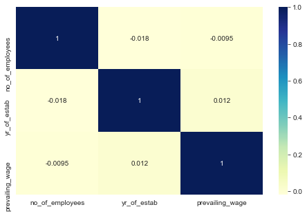

```python
# Heatmap for assessing relation
plt.figure(figsize=(8,5))
sns.heatmap(data.corr(), annot=True, cmap="YlGnBu")
plt.show()
```

- Low correlation between number of employees and prevailing wage

```python
# function to plot stacked bar chart
def stacked_barplot(data, predictor, target):
    """
    Print the category counts and plot a stacked bar chart

    data: dataframe
    predictor: independent variable
    target: target variable
    """
    count = data[predictor].nunique()
    sorter = data[target].value_counts().index[-1]
    tab1 = pd.crosstab(data[predictor], data[target], margins=True).sort_values(
        by=sorter, ascending=False
    )
    print(tab1)
    print("-" * 120)
    tab = pd.crosstab(data[predictor], data[target], normalize="index").sort_values(
        by=sorter, ascending=False
    )
    tab.plot(kind="bar", stacked=True, figsize=(count + 5, 6), cmap='YlGnBu')
    plt.legend(
        loc="lower left", frameon=False,
    )
    plt.legend(loc="upper left", bbox_to_anchor=(1, 1))
    plt.show()
```

```
case_status    Certified  Denied    All
continent
All                17018    8462  25480
Asia               11012    5849  16861
North America       2037    1255   3292
Europe              2957     775   3732
South America        493     359    852
Africa               397     154    551
Oceania              122      70    192
------------------------------------------------------------------------------------------------------------------------
```

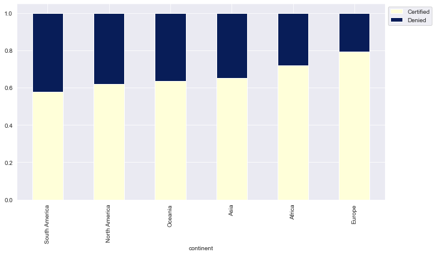

```python
stacked_barplot(data, "continent", "case_status")
```

- South America continent cases have lowest approval rate of 60%
- Europe cases are highest approval rate of 80%

```
case_status            Certified  Denied    All
education_of_employee
All                        17018    8462  25480
Bachelor's                  6367    3867  10234
High School                 1164    2256   3420
Master's                    7575    2059   9634
Doctorate                   1912     280   2192
------------------------------------------------------------------------------------------------------------------------
```

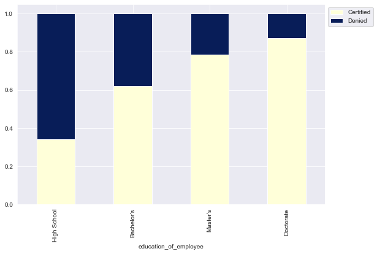

```python
stacked_barplot(data, "education_of_employee", "case_status")
```

- Employees with Doctorate have lowest Denied cases
- 80% of employees with master's have certified cases
- High schoolers have only 30% of certified cases

```
case_status         Certified  Denied    All
has_job_experience
All                     17018    8462  25480
N                        5994    4684  10678
Y                       11024    3778  14802
------------------------------------------------------------------------------------------------------------------------
```

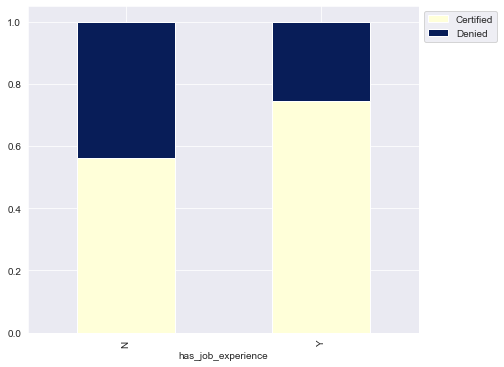

```python
stacked_barplot(data, "has_job_experience", "case_status")
```

```
case_status            Certified  Denied    All
requires_job_training
All                        17018    8462  25480
N                          15012    7513  22525
Y                           2006     949   2955
------------------------------------------------------------------------------------------------------------------------
```

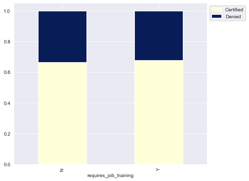

```python
stacked_barplot(data, "requires_job_training", "case_status")
```

- The certified cases distribution is about the same whether a job requires training or not

```
case_status           Certified  Denied    All
region_of_employment
All                       17018    8462  25480
Northeast                  4526    2669   7195
West                       4100    2486   6586
South                      4913    2104   7017
Midwest                    3253    1054   4307
Island                      226     149    375
------------------------------------------------------------------------------------------------------------------------
```

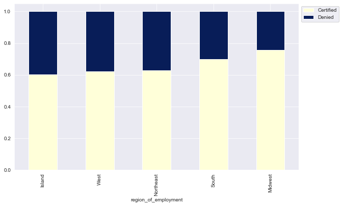

```python
stacked_barplot(data, "region_of_employment", "case_status")
```

- Island, West and Northeast have fairly similar caertified vs denied cases
- Midwest have highest certfied cases

```
case_status   Certified  Denied    All
unit_of_wage
All               17018    8462  25480
Year              16047    6915  22962
Hour                747    1410   2157
Week                169     103    272
Month                55      34     89
------------------------------------------------------------------------------------------------------------------------
```

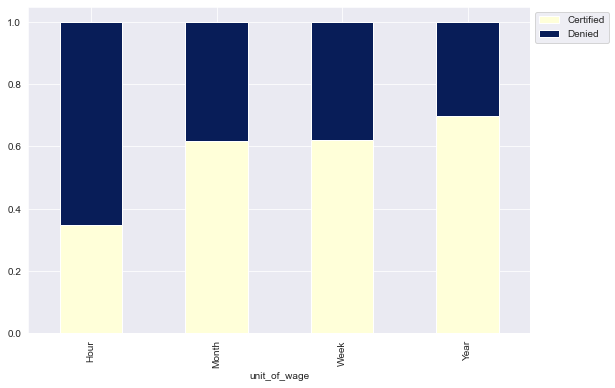

```python
stacked_barplot(data, "unit_of_wage", "case_status")
```

```
case_status         Certified  Denied    All
full_time_position
All                     17018    8462  25480
Y                       15163    7610  22773
N                        1855     852   2707
------------------------------------------------------------------------------------------------------------------------
```

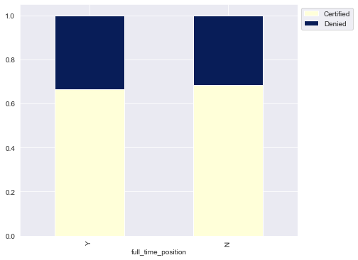

```python
stacked_barplot(data, "full_time_position", "case_status")
```

- No significant difference between full time or not

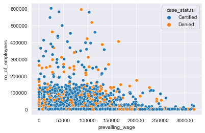

```python
sns.scatterplot(data=data, x='prevailing_wage',y='no_of_employees',hue='case_status')
plt.show()
```

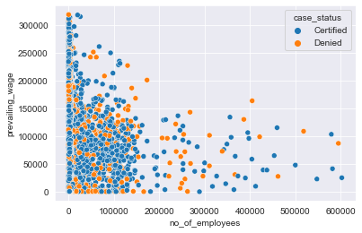

```python
sns.scatterplot(data=data, y='prevailing_wage',x='no_of_employees',hue='case_status')
plt.show()
```

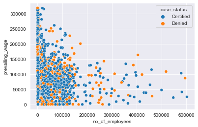

```python
sns.scatterplot(data=data, y='prevailing_wage',x='no_of_employees',hue='case_status')
plt.show()
```

- No identifiable pattern for no_of_employees and prevailing_wage for case_status

# Summary of EDA

### Data Description:

- There are 25,480 observations in the dataset
- No duplicate records in the dataset
- No missing values in the dataset

### Data Cleaning:

- Dropped column case_id as it's unique for each observation and doesn't have analytical value
- Converted all the object variables to categorical variables

### Observations from EDA:

- The number_of_employess is highly right skewed
- The year falls has range between 1800-2016
- Prevailing wage has almost normal distribution, excluding 0
- 66% percent of data is for Asia continent
- South America has lowest certfied rate of 60%
- Higher the employee education, higher number of certified cases
- Employees with prior job experience have higher number of certified cases
- Hour unit of wage have higher denied cases
- Prevailing wage and number of employees doesn't have identifiable pattern for certified cases

### Actions for Data-Preprocessing:

- Group year as it spreads around 200 years
- Remove negative values for number of employees

# Data Preprocessing

```python
print(sorted(data['yr_of_estab'].unique()))
```

```
[1800, 1801, 1804, 1807, 1809, 1810, 1817, 1818, 1819, 1820, 1821, 1822, 1823, 1824, 1830, 1831, 1832, 1833, 1834, 1836, 1837, 1838, 1839, 1840, 1841, 1842, 1843, 1845, 1846, 1847, 1848, 1849, 1850, 1851, 1852, 1853, 1854, 1855, 1856, 1857, 1858, 1859, 1860, 1861, 1862, 1863, 1864, 1865, 1866, 1867,…
```

- The year ranges from 1800 to 2016
- Let's group by decade

```python
data['nw_yr_of_estab'] = pd.cut(data['yr_of_estab'],[*range(1800,2021,10)])
```

```python
data['nw_yr_of_estab'].value_counts()
```

```
(2000, 2010]    7858
(1990, 2000]    5867
(1980, 1990]    2593
(2010, 2020]    1805
(1970, 1980]    1635
(1960, 1970]    1115
(1940, 1950]     567
(1950, 1960]     507
(1910, 1920]     425
(1880, 1890]     374
(1930, 1940]     335
(1920, 1930]     334
(1850, 1860]     308
(1900, 1910]     292
(1830, 1840]     289
(1870, 1880]     279
(1890, 1900]     272
(1860, 1870]     262
(1840, 1850]     180
(1810, 1820]      92
(1800, 1810]      48
(1820, 1830]      27
Name: nw_yr_of_estab, dtype: int64
```

```
case_status     Certified  Denied    All
nw_yr_of_estab
All                 17007    8457  25464
(2000, 2010]         5361    2497   7858
(1990, 2000]         3841    2026   5867
(1980, 1990]         1701     892   2593
(2010, 2020]         1235     570   1805
(1970, 1980]         1078     557   1635
(1960, 1970]          745     370   1115
(1940, 1950]          360     207    567
(1950, 1960]          343     164    507
(1910, 1920]          298     127    425
(1880, 1890]          250     124    374
(1920, 1930]          214     120    334
(1930, 1940]          222     113    335
(1850, 1860]          203     105    308
(1830, 1840]          187     102    289
(1900, 1910]          193      99    292
(1890, 1900]          176      96    272
(1870, 1880]          192      87    279
(1860, 1870]          181      81    262
(1840, 1850]          122      58    180
(1810, 1820]           60      32     92
(1800, 1810]           28      20     48
(1820, 1830]           17      10     27
------------------------------------------------------------------------------------------------------------------------
```

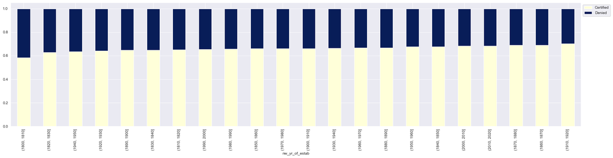

```python
stacked_barplot(data, "nw_yr_of_estab", "case_status")
```

- The year company established doesn't affect cased denied
- Let's try to group by companies before year 2000 and after 2000

```python
data['nw_yr_of_estab'] = data['yr_of_estab'].apply(lambda x: 'less_than_2000' if x < 2000 else '2000_and_greater')
```

```
case_status       Certified  Denied    All
nw_yr_of_estab
All                   17018    8462  25480
less_than_2000         9901    5110  15011
2000_and_greater       7117    3352  10469
------------------------------------------------------------------------------------------------------------------------
```

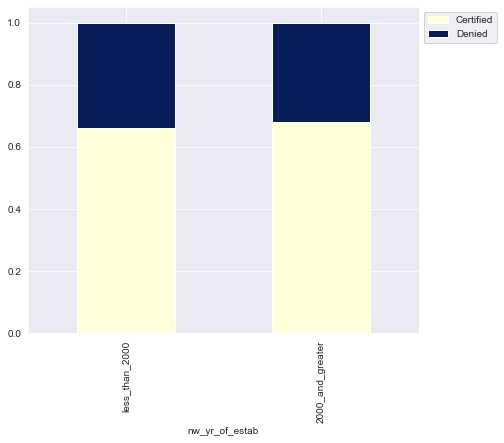

```python
stacked_barplot(data, "nw_yr_of_estab", "case_status")
```

- Grouping year established before and after 2000
- Drop year established column

```python
# drop year established
data.drop('yr_of_estab', inplace=True, axis=1)
```

```python
data[data['no_of_employees']<1]
```

|  | continent | education_of_employee | has_job_experience | requires_job_training | no_of_employees | region_of_employment | prevailing_wage | unit_of_wage | full_time_position | case_status | nw_yr_of_estab |
| --- | --- | --- | --- | --- | --- | --- | --- | --- | --- | --- | --- |
| 245 | Europe | Master's | N | N | -25 | Northeast | 39452.9900 | Year | Y | Certified | less_than_2000 |
| 378 | Asia | Bachelor's | N | Y | -11 | Northeast | 32506.1400 | Year | Y | Denied | 2000_and_greater |
| 832 | South America | Master's | Y | N | -17 | South | 129701.9400 | Year | Y | Certified | 2000_and_greater |
| 2918 | Asia | Master's | Y | N | -26 | Midwest | 112799.4600 | Year | Y | Certified | 2000_and_greater |
| 6439 | Asia | Bachelor's | N | N | -14 | South | 103.9700 | Hour | Y | Denied | 2000_and_greater |
| 6634 | Asia | Bachelor's | Y | N | -26 | West | 5247.3200 | Year | Y | Denied | less_than_2000 |
| 7224 | Europe | Doctorate | N | N | -25 | Midwest | 141435.9500 | Year | Y | Certified | less_than_2000 |
| 7281 | Asia | High School | N | N | -14 | Midwest | 58488.5000 | Year | Y | Denied | 2000_and_greater |
| 7318 | Asia | Bachelor's | Y | Y | -26 | South | 115005.6100 | Year | Y | Certified | 2000_and_greater |
| 7761 | Asia | Master's | N | N | -11 | Midwest | 38457.5100 | Year | Y | Certified | 2000_and_greater |
| 9872 | Europe | Master's | Y | N | -26 | South | 37397.0500 | Year | Y | Certified | less_than_2000 |
| 11493 | Asia | High School | Y | N | -14 | South | 27599.3500 | Year | Y | Denied | less_than_2000 |
| 13471 | North America | Master's | N | N | -17 | Northeast | 257.2413 | Hour | Y | Denied | 2000_and_greater |
| 14022 | Asia | Bachelor's | N | Y | -11 | Northeast | 108403.5600 | Year | Y | Certified | less_than_2000 |
| 14146 | Asia | Bachelor's | N | Y | -26 | West | 81982.2700 | Year | Y | Certified | less_than_2000 |
| 14726 | Asia | Master's | N | N | -11 | Midwest | 167851.8000 | Year | Y | Certified | 2000_and_greater |
| 15600 | Asia | Bachelor's | N | N | -14 | South | 24641.6100 | Year | Y | Denied | 2000_and_greater |
| 15859 | Asia | High School | N | N | -11 | South | 44640.6000 | Year | Y | Denied | less_than_2000 |
| 16157 | Asia | Master's | Y | N | -11 | South | 62681.2500 | Year | Y | Certified | less_than_2000 |
| 16883 | North America | Bachelor's | Y | N | -26 | Northeast | 168.1558 | Hour | Y | Denied | less_than_2000 |
| 17006 | Asia | Doctorate | Y | N | -11 | West | 25753.5100 | Year | Y | Denied | less_than_2000 |
| 17655 | North America | Bachelor's | Y | N | -17 | Northeast | 129753.1800 | Year | Y | Denied | 2000_and_greater |
| 17844 | Asia | Bachelor's | N | N | -14 | West | 29325.8500 | Year | Y | Denied | 2000_and_greater |
| 17983 | Asia | Bachelor's | N | N | -26 | South | 84359.9800 | Year | Y | Denied | 2000_and_greater |
| 20815 | Asia | Bachelor's | N | Y | -17 | West | 91897.5700 | Year | Y | Certified | less_than_2000 |
| 20984 | Europe | Doctorate | Y | N | -14 | Midwest | 37012.8000 | Year | Y | Certified | less_than_2000 |
| 21255 | North America | High School | N | N | -25 | South | 99405.4700 | Year | N | Denied | less_than_2000 |
| 21760 | Asia | Bachelor's | Y | N | -25 | West | 100463.5800 | Year | Y | Certified | 2000_and_greater |
| 21944 | Africa | Master's | Y | N | -25 | Midwest | 79150.5100 | Year | Y | Certified | less_than_2000 |
| 22084 | North America | Bachelor's | Y | N | -14 | West | 691.0609 | Hour | Y | Denied | less_than_2000 |
| 22388 | Asia | Master's | Y | N | -14 | South | 17893.1100 | Year | Y | Certified | less_than_2000 |
| 23186 | Asia | Master's | N | Y | -11 | Midwest | 120195.3500 | Year | Y | Certified | 2000_and_greater |
| 23476 | Europe | Master's | Y | N | -11 | West | 95072.7500 | Year | Y | Denied | 2000_and_greater |

- Number of employees has be non-zero positive number
- Dropping those observations

```python
data.drop(data[data['no_of_employees']<1].index, inplace = True)
```

```python
data.shape
```

```
(25447, 11)
```

```python
data.info()
```

```
<class 'pandas.core.frame.DataFrame'>
Int64Index: 25447 entries, 0 to 25479
Data columns (total 11 columns):
 #   Column                 Non-Null Count  Dtype
---  ------                 --------------  -----
 0   continent              25447 non-null  category
 1   education_of_employee  25447 non-null  category
 2   has_job_experience     25447 non-null  category
 3   requires_job_training  25447 non-null  category
 4   no_of_employees        25447 non-null  int64
 5   region_of_employment   25447 non-null  category
 6   prevailing_wage        25447 non-null  float64
 7   unit_of_wage           25447 non-null  category
 8   full_time_position     25447 non-null  category
 9   case_status            25447 non-null  category
 10  nw_yr_of_estab         25447 non-null  object
dtypes: category(8), float64(1), int64(1), object(1)
memory usage: 995.3+ KB
```

```python
num_cols = ['no_of_employees','prevailing_wage']
```

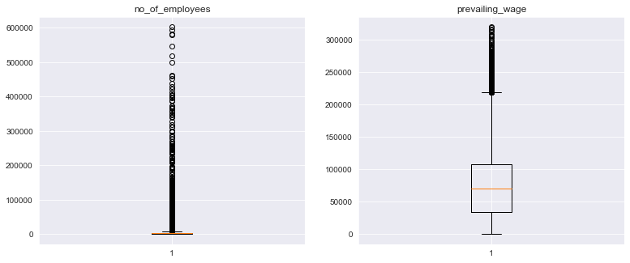

```python
# Outlier detection
# let's plot the boxplots of all columns to check for outliers
plt.figure(figsize=(20, 30))

for i, variable in enumerate(num_cols):
    plt.subplot(5, 3, i + 1)
    plt.boxplot(data[variable], whis=1.5)
    plt.title(variable)

plt.show()
```

```python
# treat outliers using IQR
# smaller values will be assigned lower whisker value and higher values will be assigned upper whisker value
def treat_outliers(data, col):
    Q1 = data[col].quantile(0.25)
    Q3 = data[col].quantile(0.75)
    IQR = Q3 - Q1
    LW = Q1 - 1.5 * IQR
    UW = Q3 + 1.5 * IQR

    # all the values smaller than Lower_Whisker will be assigned the value of Lower_Whisker
    # all the values greater than Upper_Whisker will be assigned the value of Upper_Whisker
    data[col] = np.clip(data[col], LW, UW)

    return data
```

```python
for c in num_cols:
    data = treat_outliers(data, c)
```

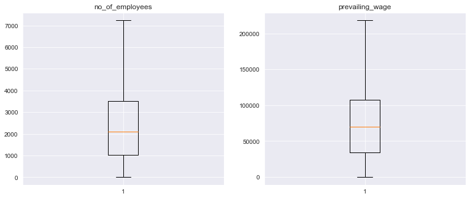

```python
# let's check boxlots after outlier treatment
plt.figure(figsize=(20, 30))

for i, variable in enumerate(num_cols):
    plt.subplot(5, 3, i + 1)
    plt.boxplot(data[variable], whis=1.5)
    plt.title(variable)

plt.show()
```

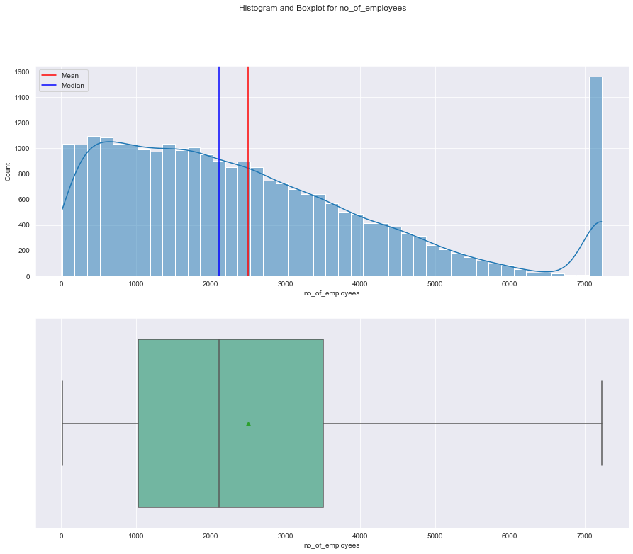

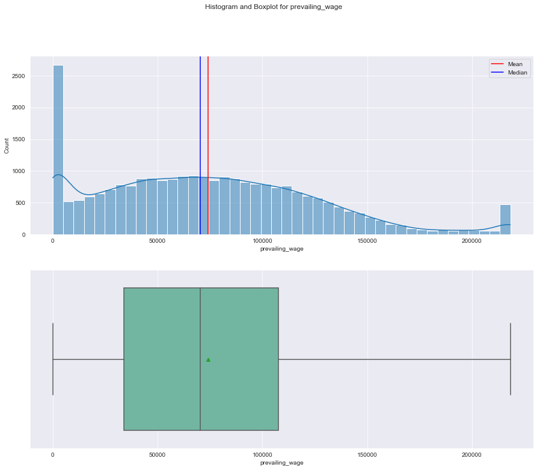

```python
# plotting numerical columns graphs
for i in num_cols:
    Hist_Bar_Plt(data[i],i)
```